# Untitled

김재혁

2022-12-23

```r
getwd()
```

```
## [1] "C:/git_blog/study/img/ch8"
```

```r
library(readxl)
library(dplyr)
library(asht)
library(lawstat)
library(kableExtra)
library(qpcR)
library(RVAideMemoire)
library(vegan)
```

**엑셀파일불러오기**

```r
#모든 시트를 하나의 리스트로 불러오는 함수
read_excel_allsheets <- function(file, tibble = FALSE) {
  sheets <- readxl::excel_sheets(file)
  x <- lapply(sheets, function(X) readxl::read_excel(file, sheet = X))
  if(!tibble) x <- lapply(x, as.data.frame)
  names(x) <- sheets
  x
}
```

## 8장

**8장 연습문제 불러오기**

```r
#data_chap08에 연습문제 8장 모든 문제 저장
data_chap08 <- read_excel_allsheets("data_chap08.xls")

#연습문제 각각 데이터 생성
for (x in 1:length(data_chap08)){
  assign(paste0('ex8_',c(1:2,'2a',7:8,10:11))[x],data_chap08[x])
  }

#연습문제 데이터 형식을 리스트에서 데이터프레임으로 변환
for (x in 1:length(data_chap08)){
  assign(paste0('ex8_',c(1:2,'2a',7:8,10:11))[x],data.frame(data_chap08[x]))
  }
```

## EXAMPLE 8.1

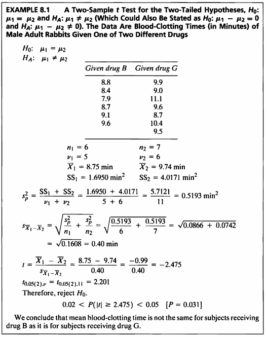

```r
#데이터셋
ex8_1%>%
  kbl(caption = "Dataset",escape=F) %>%
  kable_styling(bootstrap_options = c("striped", "hover", "condensed", "responsive"))
```

Dataset

| exam8_1.drug | exam8_1.time |
| --- | --- |
| B | 8.8 |
| B | 8.4 |
| B | 7.9 |
| B | 8.7 |
| B | 9.1 |
| B | 9.6 |
| C | 9.9 |
| C | 9.0 |
| C | 11.1 |
| C | 9.6 |
| C | 8.7 |
| C | 10.4 |
| C | 9.5 |

- 약물 B를 투여했을 때 모든 성체 수컷 토끼의 혈액 응고 시간 평균이 약물 G를 투여했을 때 모든 성체 수컷 토끼의 혈액 응고 시간 평균이 다른지 검정하고자 한다.

$$\begin{aligned}
H_0 &: \mu_1 = \mu_2 \\
H_1 &: \mu_1 \not=\ \mu_2
\end{aligned}$$

- 성체 수컷 토끼6마리에게 약물 B를 투여하였으며, 다른 성체 수컷 토끼7마리에게 추출하여 두개의 표본은 독립적이게 추출하였다.
- 이표본 t-검정을 하기 전에 두개의 표본분포의 정규성을 각각 보여야하고 두 그룹 분포간 분산이 같은지 등분산성 가정을 확인해줘야 한다.
- 정규성 검정은 P-P plot과 Q-Q plot으로도 정규성을 확인 할 수 있지만 그래프로 확인하는 정규성 검정은 기준이 모호하기 때문에 한계가 있다.
- 따라서 정규성에 대한 기타 평가 방법들을 사용할 것인데 표본의 크기가 작으므로 Shapiro-Wilk test를 사용할 것이다.  
  (표본크기가 매우 작으므로 웬만해선 정규성이 있는 것처럼 나올 것이다.)

```r
##정규성,등분산성 검정
test <- function(x,y) {
  norm1 = shapiro.test(x)$p.value
  norm2 = shapiro.test(y)$p.value
  equal.var = var.test(x,y)$p.value
  summary <- list('그룹B 샤피로윌크 p-value'=norm1, '그룹G 샤피로윌크 p-value'=norm2, '그룹B,그룹G 등분산성검정 p-value'=equal.var)
  return(summary)
}

group_B <- ex8_1 %>% filter(exam8_1.drug=='B')
group_G <- ex8_1 %>% filter(exam8_1.drug=='C')
test(group_B$exam8_1.time,group_G$exam8_1.time)
```

```
## $`그룹B 샤피로윌크 p-value`
## [1] 0.9973428
##
## $`그룹G 샤피로윌크 p-value`
## [1] 0.9132339
##
## $`그룹B,그룹G 등분산성검정 p-value`
## [1] 0.4721646
```

- 정규성 검정은 shapiro.test를 통하여 구할 수 있다.
- p-value가 정해둔 유의수준 0.05보다 크다면 유의수준 5%하에 “분포가 정규성을 따른다”는 귀무가설을 기각할 수 없다.
- 즉, p-value가 각각 0.997, 0.913 이므로 유의수준 0.05보다 크므로 유의수준 5%하에 두 집단 모두 정규성을 따르지 않는다고 할 충분한 증거가 없다.
- 등분산성 검정은 var.test (F Test to Compare Two Variances Performs an F test to compare the variances of two samples from normal populations.) 로 확인할 수 있으며 p-value가 정해둔 유의수준 0.05보다 크다면 유의수준 5%하에 “두 집단의 분산은 등분산이다”라는 귀무가설을 기각할 수 없다.
- 따라서 p-value가 0.472로 유의수준 0.05보다 크므로 유의수준 5%하에 “두 집단의 모분산은 등분산이 아니다”라고 할 충분한 근거가 없다.

> 다음은 R 내장 함수로 구한 t-value이다.

```r
t.test(group_B$exam8_1.time,group_G$exam8_1.time,var.equal = T)
```

```
##
##  Two Sample t-test
##
## data:  group_B$exam8_1.time and group_G$exam8_1.time
## t = -2.4765, df = 11, p-value = 0.03076
## alternative hypothesis: true difference in means is not equal to 0
## 95 percent confidence interval:
##  -1.8752609 -0.1104534
## sample estimates:
## mean of x mean of y
##  8.750000  9.742857
```

> 직접 함수를 작성해서 구하여 보자.

```r
two_tailed_t_test <- function(x,y){
  n1 <- length(na.omit(x))
  n2 <- length(na.omit(y))
  v1 <- n1-1
  v2 <- n2-1
  xbar1 <- mean(x)
  xbar2 <- mean(y)
  ss1 <- var(x)*v1
  ss2 <- var(y)*v2
  sp2 <- (ss1+ss2)/(v1+v2)
  s_xbar1_xbar2 <- sqrt((sp2/n1)+(sp2/n2))
  t <- (xbar1-xbar2)/s_xbar1_xbar2
  pvalue <- 2*pt(t,v1+v2)
  out <- data.frame(n1,n2,v1,v2,xbar1,xbar2=round(xbar2,2),ss1,ss2=round(ss2,4),sp2=round(sp2,4),s_xbar1_xbar2=round(s_xbar1_xbar2,2),t=round(t,3),pvalue=round(pvalue,3))
  return(out)
}

two_tailed_t_test(group_B$exam8_1.time,group_G$exam8_1.time)
```

```
##   n1 n2 v1 v2 xbar1 xbar2   ss1    ss2    sp2 s_xbar1_xbar2      t pvalue
## 1  6  7  5  6  8.75  9.74 1.695 4.0171 0.5193           0.4 -2.476  0.031
```

- 성체 수컷 토끼에게 서로 다른 약물을 투여하였을 때, 두 약물의 혈액 응고 시간에 대한 평균의 차이를 독립 이표본 t-검점을 통해 확인해 보자.
- 추출된 표본으로 계산한 통계량
  $$\bar{X}_B=8.75 \min \,\ \bar{X}_G=9.74 \min$$
- 두 표본의 등분산성을 가정하였으므로 합동분산
  $$S^2_p=0.5193$$
- t-값은 -2.475이고 양측 임계값은 2.201으로 좌측 임계값인 -2.201보다 t-값이 작으므로 기각역에 포함되어 귀무가설을 기각할 수 있다.
- 따라서 유의수준 5%하에 두 약물처리(B와G)에 따른 모든 성체 수컷토끼의 혈액 응고 시간은 다르다고 할 수 있다.

## EXAMPLE 8.2

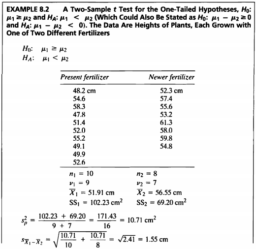

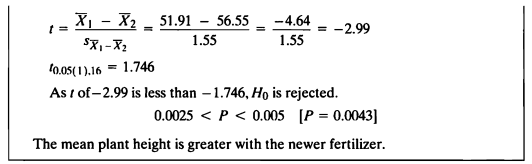

```r
#데이터셋
ex8_2%>%
  kbl(caption = "Dataset",escape=F) %>%
  kable_styling(bootstrap_options = c("striped", "hover", "condensed", "responsive"))
```

Dataset

| exam8_2.fertilizer | exam8_2.height |
| --- | --- |
| present | 48.2 |
| present | 54.6 |
| present | 58.3 |
| present | 47.8 |
| present | 51.4 |
| present | 52.0 |
| present | 55.2 |
| present | 49.1 |
| present | 49.9 |
| present | 52.6 |
| newer | 52.3 |
| newer | 57.4 |
| newer | 55.6 |
| newer | 53.2 |
| newer | 61.3 |
| newer | 58.0 |
| newer | 59.8 |
| newer | 54.8 |

- 식물의 길이가 새로운 비료를 줬을 때 기존 비료를 줬을 때보다 평균이 큰지 검정하고자 한다.

$$\begin{aligned}
H_0 &: \mu_1 \geq \mu_2 \\
H_1 &: \mu_1 < \ \mu_2
\end{aligned}$$

- 기존 비료를 10개 식물에게 새로운 비료를 8개 식물에게 줬으며 기존 비료 그룹과 새로운 비료 그룹 두개의 표본은 독립적이게 추출하였다.

```r
##정규성,등분산성 검정
test <- function(x,y) {
  norm1 = shapiro.test(x)$p.value
  norm2 = shapiro.test(y)$p.value
  equal.var = var.test(x,y)$p.value
  summary <- list('Present Shapiro-Wilk p-value'=norm1, 'Newer Shapiro-Wilk p-value'=norm2, 'Present,Newer 등분산성검정 p-value'=equal.var)
  return(summary)
}
group_pre <- ex8_2 %>% filter(exam8_2.fertilizer=='present')
group_new <- ex8_2 %>% filter(exam8_2.fertilizer=='newer')
test(group_pre$exam8_2.height,group_new$exam8_2.height)
```

```
## $`Present Shapiro-Wilk p-value`
## [1] 0.6832982
##
## $`Newer Shapiro-Wilk p-value`
## [1] 0.9021483
##
## $`Present,Newer 등분산성검정 p-value`
## [1] 0.8743753
```

- shapiro.test를 통하여 기존 비료를 준 그룹에 대한 정규성검정 p-value=0.6832이고,  
  새로운 비료를 준 그룹에 대한 p-value는 0.9021로 둘다 유의수준 5%하에 귀무가설을 기각할 수 없다.
- 즉, 유의수준 5%하에 두 집단 모두 정규성을 따르지 않는다고 할 충분한 증거가 없다.
- 등분산성 검정은 var.test을 통하여 p-value=0.8744로 정해둔 유의수준 0.05보다 크므로 유의수준 5%하에 “두 집단의 분산은 등분산이다”라는 귀무가설을 기각할 수 없다.
- 따라서 유의수준 5%하에 “두 집단의 모분산은 등분산이 아니다”라고 할 충분한 근거가 없다.

> 다음은 R 내장 함수로 구한 t-value이다.

```r
t.test(group_pre$exam8_2.height,group_new$exam8_2.height,var.equal = T, alternative = "less")
```

```
##
##  Two Sample t-test
##
## data:  group_pre$exam8_2.height and group_new$exam8_2.height
## t = -2.9884, df = 16, p-value = 0.004343
## alternative hypothesis: true difference in means is less than 0
## 95 percent confidence interval:
##       -Inf -1.929255
## sample estimates:
## mean of x mean of y
##     51.91     56.55
```

> 직접 함수를 작성해서 구하여 보자.

```r
one_tailed_t_test <- function(x,y){
  n1 <- length(na.omit(x))
  n2 <- length(na.omit(y))
  v1 <- n1-1
  v2 <- n2-1
  xbar1 <- mean(x)
  xbar2 <- mean(y)
  ss1 <- var(x)*v1
  ss2 <- var(y)*v2
  sp2 <- (ss1+ss2)/(v1+v2)
  s_xbar1_xbar2 <- sqrt((sp2/n1)+(sp2/n2))
  t <- (xbar1-xbar2)/s_xbar1_xbar2
  pvalue <- pt(t,v1+v2)
  out <- data.frame(n1,n2,v1,v2,xbar1,xbar2=round(xbar2,2),ss1=round(ss1,3),ss2=round(ss2,4), s_xbar1_xbar2=round(s_xbar1_xbar2,2),t=round(t,3),pvalue=round(pvalue,4))
  return(out)
}
one_tailed_t_test(group_pre$exam8_2.height,group_new$exam8_2.height)
```

```
##   n1 n2 v1 v2 xbar1 xbar2     ss1  ss2 s_xbar1_xbar2      t pvalue
## 1 10  8  9  7 51.91 56.55 102.229 69.2          1.55 -2.988 0.0043
```

## EXAMPLE 8.2

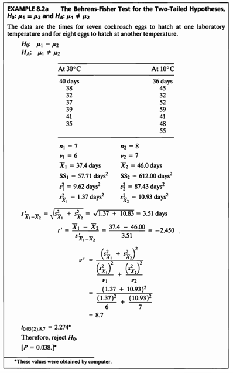

```r
#데이터셋
ex8_2a%>%
  kbl(caption = "Dataset",escape=F) %>%
  kable_styling(bootstrap_options = c("striped", "hover", "condensed", "responsive"))
```

Dataset

| exam8_2a.temp | exam8_2a.days |
| --- | --- |
| 30 | 40 |
| 30 | 38 |
| 30 | 32 |
| 30 | 37 |
| 30 | 39 |
| 30 | 41 |
| 30 | 35 |
| 10 | 36 |
| 10 | 45 |
| 10 | 32 |
| 10 | 52 |
| 10 | 59 |
| 10 | 41 |
| 10 | 48 |
| 10 | 55 |

- 서로 다른 실험실 온도에서 바퀴벌레 알이 부화하는 평균 시간이 다른지 검정하고자 한다.
- 실험실 온도에 따른 바퀴벌레 알의 부화 일수 평균에 대한 가설

$$\begin{aligned}
H_0 &: \mu_{30} = \mu_{10} \\
H_1 &: \mu_{30} \not=\ \mu_{10}
\end{aligned}$$
- 30도에서 7개의 알을, 10도에서 8개의 알이 부화하는 시간을 관찰하여 기록하였고 두개의 표본은 독립적이게 추출하였다.

```r
##정규성,등분산성 검정
test <- function(x,y) {
  norm1 = shapiro.test(x)$p.value
  norm2 = shapiro.test(y)$p.value
  equal.var = var.test(x,y)$p.value
  summary <- list('30도 실험실 p-value'=norm1, '10도 실험실 p-value'=norm2, '30,10 등분산성검정 p-value'=equal.var)
  return(summary)
}
group_30 <- ex8_2a %>% filter(exam8_2a.temp==30)
group_10 <- ex8_2a %>% filter(exam8_2a.temp==10)

test(group_30$exam8_2a.days,group_10$exam8_2a.days)
```

```
## $`30도 실험실 p-value`
## [1] 0.7312982
##
## $`10도 실험실 p-value`
## [1] 0.9415191
##
## $`30,10 등분산성검정 p-value`
## [1] 0.01564653
```

- shapiro.test를 통하여 30도 실험실 그룹에 대한 정규성검정 p-value=0.7312이고,  
  10도 실험실 그룹에 대한 p-value는 0.9415로 둘다 유의수준 5%하에 귀무가설을 기각할 수 없다.
- 즉, 유의수준 5%하에 두 집단 모두 정규성을 따르지 않는다고 할 충분한 증거가 없다.
- 등분산성 검정은 var.test을 통하여 p-value=0.0156으로 정해둔 유의수준 0.05보다 작으므로 유의수준 5%하에 “두 집단의 분산은 등분산이다”라는 귀무가설을 기각할 수 있다.
- 따라서 유의수준 5%하에 “두 집단의 모분산은 등분산이 아니다”라고 할 수 있다.
- 두 모집단이 정규분포를 따르지만 분산이 다른 경우는 Behrens-Fisher 검정을 이용한다.

```r
library(asht) #Behrens-Fisher검정을 하기 위한 패키지
#sample size for t-tests with different variances and non-equal n per arm, Behrens-Fisher test, nonparametric ABC intervals, Wilcoxon-Mann-Whitney test 등등 구할 수 있다.
bfTest(group_30$exam8_2a.days,group_10$exam8_2a.days,altenative=c("two.sided"),mu=0,conf.level=0.95)
```

```
##
##  Behrens-Fisher test
##
## data:  x=group_30$exam8_2a.daysand y=group_10$exam8_2a.days
## t = -2.4437, R = 0.34076, p-value = 0.04436
## alternative hypothesis: true difference in means is not equal to 0
## 95 percent confidence interval:
##  -16.8684039  -0.2744532
## sample estimates:
## mean of x mean of y
##  37.42857  46.00000
```

- 30도 실험실의 바퀴벌레 알의 부화 일수 평균은 37.4days이고 10도 실험실의 바퀴벌레 알의 부화 일수 평균은 46days이다.

$$\sqrt{S^2_\bar{X_{30}}+S^2_\bar{X_{10}}}=3.51 \ days$$

- t-값은 -2.44이고 양측 임계값은 2.274이다. 좌측 임계값인 -2.274보다 t-값이 작으므로 귀무가설을 기각할 수 있다.
- 따라서 온도가 30도인 실험실과 10도인 실험실에서 바퀴벌레 알의 부화 일수의 모평균에는 차이가 있다고 할 수 있다.  
  (95% 신뢰구간을 확인해 보면 (-16.87,-0.27)로 0을 포함하고 있지 않으므로 두 집단간 모평균에는 차이가 있다고 볼 수 있다.)

## EXAMPLE 8.3

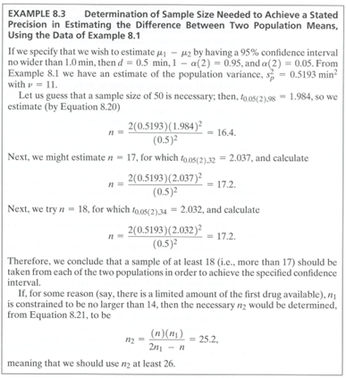

- 정밀도를 이용한 모평균차에 대한 표본크기계산
- 정밀도 d가 주어졌을 때
  $$1-\alpha%$$
  신뢰구간에 들어갈 수 있는 최소 표본 크기

$$n=\frac
{2*s^2_p*t^2_{(\alpha/2,n_1+n_2-2)}}{d^2} \ _{(양측)}$$

$$n=\frac
{2*s^2_p*t^2_{(\alpha,n_1+n_2-2)}}{d^2} \ _{(단측)}$$

> 직접 함수를 작성해서 구하여 보자.

```r
d.sample <- function(x,y, d,alpha,en,side) {
  if(sum(is.na(x)) >= 1) {
  x=na.omit(x)
  }
  else if (sum(is.na(y)) >= 1){
    y=na.omit(y)
  }
  else
    {
    x=x
    y=y
  }
  n1= length(x)
  n2= length(y)
  df1=n1-1
  df2= n2-1
  new_df= en-1
  x.bar1= round(mean(x),2)
  x.bar2= round(mean(y),2)
  ss1=round(sum(x^2) - ((sum(x))^2/n1), 4)
  ss2=round(sum(y^2) - ((sum(y))^2/n2),4)

  sp= round((ss1 + ss2)/(df1+df2),4)
  if (side == "two"){
    ct = round(abs(qt(alpha/2,2*new_df)),3)
  }
  else{
    ct = round(abs(qt(alpha,2*new_df)),3)
  }
  size1= ceiling(2*sp*(ct^2) / (d^2))
  s=round((2*sp*(ct^2))/(0.5)^2,1)
  result <- list(spsquare=sp, '임계값'=ct, n=s ,sample_size=size1)
  return(result)
}
```

```r
d.sample(group_B$exam8_1.time,group_G$exam8_1.time, 0.5, 0.05, 50,'two')
```

```
## $spsquare
## [1] 0.5193
##
## $임계값
## [1] 1.984
##
## $n
## [1] 16.4
##
## $sample_size
## [1] 17
```

> 정밀도 d=0.5이고 $s^2_p$=0.5193 표본크기를 50으로 추정하였을 때 $t_{0.05(2),98}$=1.984이고 표본크기는 16.4가 나온다.

```r
d.sample(group_B$exam8_1.time,group_G$exam8_1.time, 0.5, 0.05, 17,'two')
```

```
## $spsquare
## [1] 0.5193
##
## $임계값
## [1] 2.037
##
## $n
## [1] 17.2
##
## $sample_size
## [1] 18
```

> 정밀도 d=0.5이고 $s^2_p$=0.5193 표본크기를 17로 추정하였을 때 $t_{0.05(2),32}$=2.037이고 표본크기는 17.2가 나온다.

```r
d.sample(group_B$exam8_1.time,group_G$exam8_1.time, 0.5, 0.05, 18,'two')
```

```
## $spsquare
## [1] 0.5193
##
## $임계값
## [1] 2.032
##
## $n
## [1] 17.2
##
## $sample_size
## [1] 18
```

$$n=\frac{k}{\frac{1}{n_1}\ldots\frac{1}{n_k}}
\ ,\ _{k는} \ _{그룹수}$$

- 조화 평균을 이용해서 계산한다.
- 그룹1의 표본크기
  $$n_1$$
  를 고정시키고 그룹 2의 표본크기
  $$n_2$$
  를 구하는 경우 (위 식과 동일)

$$n_2 = \frac{nn_1}{2n_1-n}$$

- 예를 들어 $n$(그룹별 표본크기)=18, $n_1$=14인 경우

```r
n=18
n1=14
n2=n*n1 / (2*n1-n)
n2
```

```
## [1] 25.2
```

> $$n_2$$
> =25.2 , 약 26이다.

**최소 요구되는 총 표본크기는 14+26=40**

## EXAMPLE 8.4

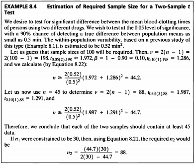

$$\begin{aligned}
n &\ge
\frac{2s_p^2}{\delta^2}(t_{(\frac{\alpha}{2},n_1+n_2-2)}+t_{(\beta,n_1+n_2-2)})^2 \
_{(양측)}
\end{aligned}$$

$$\begin{aligned}
n &\ge
\frac{2s_p^2}{\delta^2}(t_{(\alpha,n_1+n_2-2)}+t_{(\beta,n_1+n_2-2)})^2 \
_{(단측)}
\end{aligned}$$

- 표본 크기가 100일 때,자유도=100+100-2=198이고 이에 대응되는 임계값

```r
t_alpha <- round(qt(0.025, 198,lower.tail = F),3)
t_beta <- round(qt(0.10,198,lower.tail = F), 3)
```

```r
t_alpha
```

```
## [1] 1.972
```

> $$t_{0.05(2),198}=1.972$$

```r
t_beta
```

```
## [1] 1.286
```

> $$t_{0.10(1),198}=1.286$$

```r
bound <- round(2*0.52 / 0.5^2 *(t_alpha+t_beta)^2, 1)
bound
```

```
## [1] 44.2
```

> $$n \ge 44.2$$
- 표본 크기가 45일 때,자유도=45+45-2=88이고 이에 대응되는 임계값

```r
t_alpha <- round(qt(0.025, 88,lower.tail = F),3)
t_beta <- round(qt(0.10,88,lower.tail = F), 3)
```

```r
t_alpha
```

```
## [1] 1.987
```

> $$t_{0.05(2),88}=1.987$$

```r
t_beta
```

```
## [1] 1.291
```

> $$t_{0.10(1),88}=1.291$$

```r
bound <- round(2*0.52 / 0.5^2 *(t_alpha+t_beta)^2, 1)
bound
```

```
## [1] 44.7
```

> $$n \ge 44.7$$
- 따라서 두 표본의 크기는 각각 최소한 45 이상이여야 한다.
- 그룹1의 표본크기
  $$n_1$$
  =30으로 고정시키고 그룹 2의 표본크기
  $$n_2$$
  를 구하는 경우

```r
n=44.7
n1=30
n2=n*n1 / (2*n1-n)
n2
```

```
## [1] 87.64706
```

> n(그룹별 표본 크기)은 위에서 구한 44.7로 두고
> $$n_1$$
> =30으로 고정되어 있을 때
> $$n_2$$
> 는 88이다.

## EXAMPLE 8.5

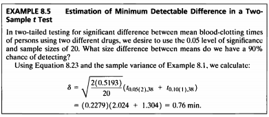

- 최소 검출차 (minimum detectable difference:MDD)

$$\delta \ge
\sqrt{\frac{2s_p^2}{n}}t_{(\frac{\alpha}{2},n_1+n_2-2)}+t_{(\beta,n_1+n_2-2)} \
_{(양측)}$$

$$\delta \ge
\sqrt{\frac{2s_p^2}{n}}t_{(\alpha,n_1+n_2-2)}+t_{(\beta,n_1+n_2-2)} \
_{(단측)}$$

```r
delta <- sqrt(2*0.5193 / 20)*(qt(0.025,38,lower.tail = F) + qt(0.1,38,lower.tail = F))
round(delta, 2)
```

```
## [1] 0.76
```

$$n$$
(표본 크기)=20,
$$\alpha$$
=0.05,
$$\beta$$
=1-0.9=0.1로 주어졌을 때 검출 가능한 최소 차이는 0.76min이다.

## EXAMPLE 8.6

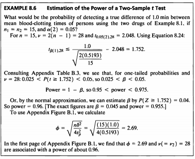

- Example 8.1에 대하여
  $$n_1=n_2=15$$
  , and
  $$\alpha(2)=0.05$$
  하에 두 약물을 사용하여 사람의 평균 혈액 응고 시간 간에 1분의 차이를 검출할 확률
- 검정력 공식

$$\ t_{(\beta,n_1+n_2-2)} \leq \frac{\delta}{\sqrt{\frac{2s^2_p}{n}}} \
-t_{(\frac{\alpha}{2},n_1+n_2-2)} \ _{(양측)}$$

$$\ t_{(\beta,n_1+n_2-2)} \leq \frac{\delta}{\sqrt{\frac{2s^2_p}{n}}} \
-t_{(\alpha,n_1+n_2-2)} \ _{(단측)}$$

```r
delta <- 1
n <- 15
sp <- 0.5193
t_alpha<- 2.048
t_beta <- delta/(sqrt((2*sp)/15))-t_alpha
round(t_beta,3)
```

```
## [1] 1.752
```

$$\ t_{(\beta(1),28)} \leq 1.752$$

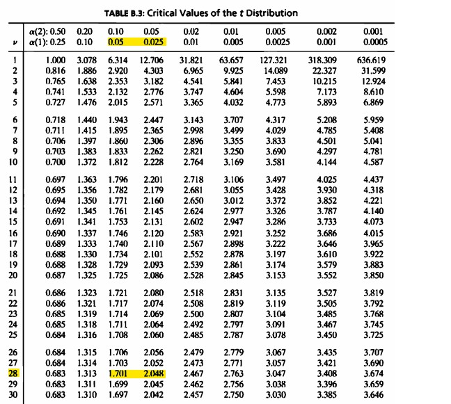

- $$P(t\geq1.752)$$
  (단측) 자유도=28인 확률은 (0.025,0.05)구간에 있다. 따라서
  $$0.025<\beta<0.05$$

$$Power=1-\beta, \ so \
0.95<power<0.975$$

- 표준정규분포 근사 값으로 구한 정규분포 확률은
  $$\beta \ by \ P(Z\geq1.752)=0.04$$
  이다. 따라서 power=0.96이다.

$$\phi=\sqrt{(\frac{n\delta^2}{4s^2_p})}=\sqrt{(\frac{15(1.0)^2}{4(0.5193)})}=2.69$$

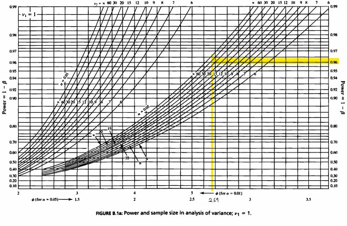

- 표를 참고하여 보면
  $$\phi=2.69 \ and \
  \nu(=\nu_2)=28$$
  은 약 0.96의 검정력과 관련이 있게 나온다.

## EXAMPLE 8-7

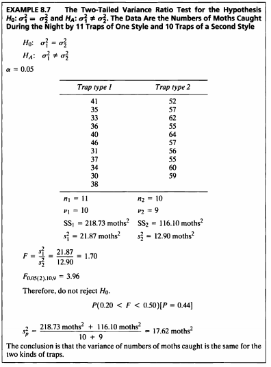

- type1,type2인 trap에 따라 잡히는 나방의 수의 표본을 구했다.
- trap 종류에 따라 잡힌 나방의 수에 대한 분산의 비가 다른가에 대한 검정으로 모집단의 분산 차이가 있는지 알아보고자 한다.

$$\ H_0:\sigma^2_1 = \sigma^2_2 \ vs \ H_1: \sigma^2_1 \not= \sigma^2_2$$

```r
##정규성,등분산성 검정
test <- function(x,y) {
  norm1 = shapiro.test(x)$p.value
  norm2 = shapiro.test(y)$p.value
  summary <- list('type1 샤피로윌크 p-value'=norm1, 'type2 샤피로윌크 p-value'=norm2)
  return(summary)
}
group_1 <- ex8_7 %>% filter(exam8_7.trap==1)
group_2 <- ex8_7 %>%  filter(exam8_7.trap==2)

test(group_1$exam8_7.number,group_2$exam8_7.number)
```

```
## $`type1 샤피로윌크 p-value`
## [1] 0.8921986
##
## $`type2 샤피로윌크 p-value`
## [1] 0.9156178
```

- 분산비를 검정하기 전에 각 모집단의 표본이 정규성을 따르는지 shapiro-wilk test로 검정하였다.
- shapiro-wilk p-value가 각각 0.892, 0.916 이므로 유의수준 0.05보다 크므로 유의수준 5%하에 두 집단 모두 정규성을 따르지 않는다고 할 충분한 증거가 없다.

```r
n1 <- length(group_1$exam8_7.number)
n2 <- length(group_2$exam8_7.number)
var1 <- round(var(group_1$exam8_7.number), 2)
var2 <- round(var(group_2$exam8_7.number), 2)
F_stat <- round(var1 / var2, 2)
list(n1=n1, n2=n2, var1=var1, var2=var2,"F"=F_stat)
```

```
## $n1
## [1] 11
##
## $n2
## [1] 10
##
## $var1
## [1] 21.87
##
## $var2
## [1] 12.9
##
## $F
## [1] 1.7
```

## EXAMPLE 8-8

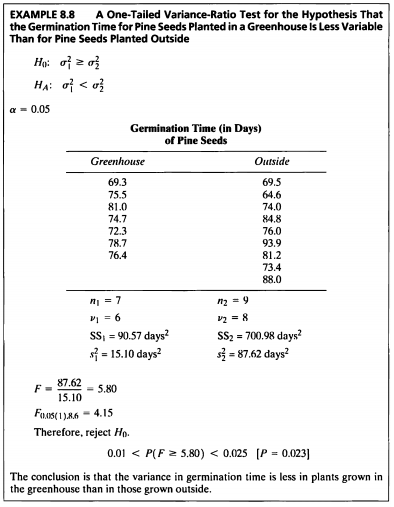

```r
#데이터셋
ex8_8%>%
  kbl(caption = "Dataset",escape=F) %>%
  kable_styling(bootstrap_options = c("striped", "hover", "condensed", "responsive"))
```

Dataset

| exam8_8.site | exam8_8.time |
| --- | --- |
| 1 | 69.3 |
| 1 | 75.5 |
| 1 | 81.0 |
| 1 | 74.7 |
| 1 | 72.3 |
| 1 | 78.7 |
| 1 | 76.4 |
| 2 | 69.5 |
| 2 | 64.6 |
| 2 | 74.0 |
| 2 | 84.8 |
| 2 | 76.0 |
| 2 | 93.9 |
| 2 | 81.2 |
| 2 | 73.4 |
| 2 | 88.0 |

- Greenhouse,Outside에서 소나무 종자 발아 시간을 각각 측정하였다.
- 두 상황에서 추출한 두 데이터로 Outside에서의 소나무 종자 발아 시간의 모분산이 Greenhouse에서 보다 모분산이 더 큰지 검정하고자 한다.

$$\ H_0:\sigma^2_1 \geq \sigma^2_2 \ vs \ H_1: \sigma^2_1 < \sigma^2_2$$

```r
##정규성,등분산성 검정
test <- function(x,y) {
  norm1 = shapiro.test(x)$p.value
  norm2 = shapiro.test(y)$p.value
  summary <- list('Greenhouse 샤피로윌크 p-value'=norm1, 'Outside 샤피로윌크 p-value'=norm2)
  return(summary)
}
group_G <- ex8_8 %>% filter(exam8_8.site==1)
group_O <- ex8_8 %>% filter(exam8_8.site==2)

test(group_G$exam8_8.time,group_O$exam8_8.time)
```

```
## $`Greenhouse 샤피로윌크 p-value`
## [1] 0.993425
##
## $`Outside 샤피로윌크 p-value`
## [1] 0.9566238
```

- 분산비를 검정하기 전에 각 모집단의 표본이 정규성을 따르는지 shapiro-wilk test로 검정하였다.
- shapiro-wilk p-value가 각각 0.993, 0.956 이므로 유의수준 0.05보다 크므로 유의수준 5%하에 두 집단 모두 정규성을 따르지 않는다고 할 충분한 증거가 없다.

```r
n1 <- length(group_G$exam8_8.time)
n2 <- length(group_O$exam8_8.time)
var1 <- round(var(group_G$exam8_8.time), 2)
var2 <- round(var(group_O$exam8_8.time), 2)
F_stat <- round(var2 / var1, 2)
list(n1=n1, n2=n2, var1=var1, var2=var2,"F"=F_stat)
```

```
## $n1
## [1] 7
##
## $n2
## [1] 9
##
## $var1
## [1] 15.09
##
## $var2
## [1] 87.62
##
## $F
## [1] 5.81
```

- 각각의 분산은
  $$s^2_1=15.10$$
  ,
  $$s^2_2=87.62$$
  이고,
  $$F=\frac{s^2_1}{s^2_2} \ or \
  F=\frac{s^2_2}{s^2_1}$$
  둘 중 큰 값을 사용한다.
  따라서
  $$F=\frac{s^2_2}{s^2_1}=
  \frac{87.62}{15.10}=5.80$$
  이다.
- F-값이 임계값
  $$F_{0.05(1),8,6}=4.15$$
  보다 크므로 기각역에 포함되고 귀무가설을 기각할 수 있다.
- 따라서 Greenhouse에서 소나무 종자 발아 시간 모분산은 Outside에서 소나무 종자 발아 시간 모분산 보다 작다고 할 수 있다.

## EXAMPLE 8-9

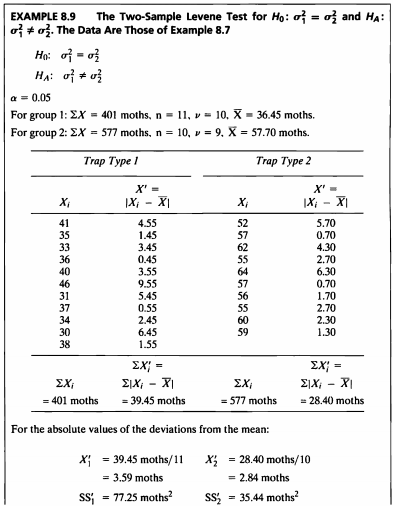

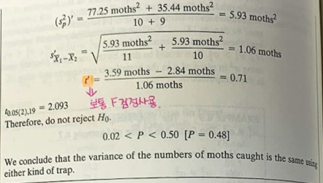

```r
library(lawstat) #levene test를 위한 패키지
levene.test(ex8_7$exam8_7.number,ex8_7$exam8_7.trap,location='mean')
```

```
##
##  Classical Levene's test based on the absolute deviations from the mean
##  ( none not applied because the location is not set to median )
##
## data:  ex8_7$exam8_7.number
## Test Statistic = 0.49267, p-value = 0.4913
```

- Levene test를 통하여 분산의 동일성 검정을 할 수 있다.
- Levene test는 모집단이 정규분포를 따르지 않는 경우에 모분산의 동질성을 검정하기 위하여 사용한다.
- p-value = 0.4913으로 출력된 것을 볼 수 있다. 그러므로 유의수준 5%하에서 귀무가설을 기각할 충분한 근거가 없다.

> 두 종류의 trap에 따라 잡히는 나방의 수의 모분산이 같지 않다는 증거가 충분하지 않다고 할 수 있다.

## EXAMPLE 8-10

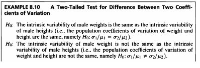

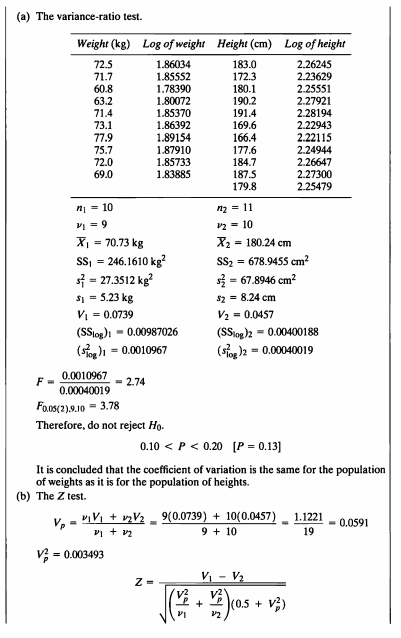

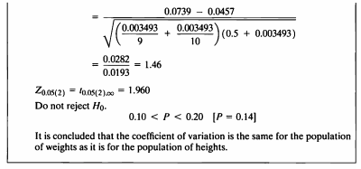

```r
#데이터셋
ex8_10%>%
  kbl(caption = "Dataset",escape=F) %>%
  kable_styling(bootstrap_options = c("striped", "hover", "condensed", "responsive"))
```

Dataset

| exam8_10.weight | exam8_10.height |
| --- | --- |
| 72.5 | 183.0 |
| 71.700000000000003 | 172.3 |
| 60.799999999999997 | 180.1 |
| 63.200000000000003 | 190.2 |
| 71.400000000000006 | 191.4 |
| 73.099999999999994 | 169.6 |
| 77.900000000000006 | 166.4 |
| 75.700000000000003 | 177.6 |
| 72 | 184.7 |
| 69 | 187.5 |
| . | 179.8 |

- 같은 모집단에서 추출된 남성의 키와 몸무게의 변동이 다른지를 검정하고자 한다.
- 키의 측정 단위는 cm이고, 몸무게의 측정단위는 kg이다.
- 단위가 다른 두 데이터의 비교를 위해 변동계수 (coefficients of variantion)을 산출하여 비교하였다.
- 따라서 가설은 다음과 같이 설정할 수 있다.

$$\begin{aligned}
H_0 &:\frac{\sigma_1}{\mu_1}=\frac{\sigma_2}{\mu_2}, \\
H_1 &:\frac{\sigma_1}{\mu_1} \neq \frac{\sigma_2}{\mu_2}
\end{aligned}$$

```r
##정규성,등분산성 검정
test <- function(x,y) {
  norm1 = shapiro.test(x)$p.value
  norm2 = shapiro.test(y)$p.value
  summary <- list('weight 샤피로윌크 p-value'=norm1, 'height 샤피로윌크 p-value'=norm2)
  return(summary)
}

test(as.numeric(ex8_10$exam8_10.weight),as.numeric(ex8_10$exam8_10.height))
```

```
## $`weight 샤피로윌크 p-value`
## [1] 0.2660832
##
## $`height 샤피로윌크 p-value`
## [1] 0.7483809
```

- p-value가 각각
  $$p\ value=0.2661,\
  0.7484$$
  으로 유의수준 0.05보다 크기에 귀무가설
  $$H_0$$
  를 기각할만한 충분한 근거가 없다. 데이터셋이 정규성을 따르지 않는다는 충분한 근거가 없기에 분산 비의 검정을 수행할 수 있다.
- 분산비 검정을 하기 위하여 통계량 구하는 함수를 작성하여 보자.

```r
library(kableExtra)
f8_10 <- function(x,y){
  x <- na.omit(x)
  y <- na.omit(y)
  n1 <- length(x)
  n2 <- length(y)
  v1 <- n1-1
  v2 <- n2-1
  xbar1 <- mean(x)
  xbar2 <- mean(y)
  s1 <-var(x)
  s2 <- var(y)
  ss1 <- var(x)*v1
  ss2 <- var(y)*v2
  sd1 <- sd(x)
  sd2 <- sd(y)
  cv1 <- sd1/xbar1
  cv2 <- sd2/xbar2
  sslog1 <- var(log10(x))*v1
  sslog2 <- var(log10(y))*v2
  slog1 <- var(log10(x))
  slog2 <- var(log10(y))
  if(slog1 > slog2){
    f <- slog1/slog2
  }
  else{
    f <- slog2/slog1
  }
  pvalue <- 2*(1-pf(f,max(v1,v2),min(v1,v2)))
  if(pvalue < 0.05){
    Reject_H0 <- "yes"
    sp2 <- NA
  }
  else{
    Reject_H0 <- "No"
  }
  out1 <- c(n=n1,v=v1,xbar=round(xbar1,2), s_2=round(s1,4),s=round(ss1,4),CV =round(cv1,4),SSlog=round(sslog1,8),s_2log=round(slog1,8),F=round(f,2),
                    pvalue=round(pvalue,2),Reject_H0)
  out2 <- c(n=n2,v=v2,xbar=round(xbar2,2), s_2=round(s2,4),s=round(ss2,4),CV =round(cv2,4),SSlog=round(sslog2,8),s_2log=round(slog2,8),F=round(f,2),
                    pvalue=round(pvalue,2),Reject_H0)
  out <-as.data.frame(cbind(out1,out2))
  names(out) <- c("Weight","Height")
  rownames(out)[11] <- "Reject_H0"
  return(out)
}

f8_10(as.numeric(ex8_10$exam8_10.weight),as.numeric(ex8_10$exam8_10.height)) %>%
  kbl(caption = "Result of Variance ratio test") %>%
   kable_styling(bootstrap_options = c("striped", "hover", "condensed", "responsive"))
```

Result of Variance ratio test

|  | Weight | Height |
| --- | --- | --- |
| n | 10 | 11 |
| v | 9 | 10 |
| xbar | 70.73 | 180.24 |
| s_2 | 27.3512 | 67.8945 |
| s | 246.161 | 678.9455 |
| CV | 0.0739 | 0.0457 |
| SSlog | 0.00986951 | 0.00400214 |
| s_2log | 0.00109661 | 0.00040021 |
| F | 2.74 | 2.74 |
| pvalue | 0.14 | 0.14 |
| Reject_H0 | No | No |

- 몸무게의 CV=0.0739, 키의 CV=0.0457
- Lewontin은 data를 logarithmic transformation하여 변동계수 검정을 수행하는 방법을 증명하였다.
  각 표본의 data들에 log10 변환을 하여 산출한 분산은 몸무게=0.0010967, 키=0.00040019이고,
  이를 활용한 F-value는
  $$F=\frac{0.0010967}{0.00040019}=2.74$$
  이다.
  임계값보다 F-value가 작으므로 귀무가설을 기각할 수 없다.

> 즉, 같은 모집단으로부터 추출된 남성의 키와 몸무게의 변동은 다르다고 할 증거가 충분하지 못하다.

```r
cv1 <- as.numeric(f8_10(as.numeric(ex8_10$exam8_10.weight),as.numeric(ex8_10$exam8_10.height))$Weight[6])
cv2 <- as.numeric(f8_10(as.numeric(ex8_10$exam8_10.weight),as.numeric(ex8_10$exam8_10.height))$Height[6])
v1 <- as.numeric(f8_10(as.numeric(ex8_10$exam8_10.weight),as.numeric(ex8_10$exam8_10.height))$Weight[2])
v2 <- as.numeric(f8_10(as.numeric(ex8_10$exam8_10.weight),as.numeric(ex8_10$exam8_10.height))$Height[2])
vp <- (v1*cv1+v2*cv2)/(v1+v2)
vp2 <- round(vp,4)^2
Z <- (cv1-cv2)/sqrt(((vp2/v1)+(vp2/v2))*(0.5+vp2))
pvalue <- 2*(1-pt(Z,v1+v2))

if(pvalue < 0.05){
  Reject_H0 <- "yes"
}else{
  Reject_H0 <- "No"
}

ztest <- data.frame(vp=round(vp,4),vp2=round(vp2,6),Z=round(Z,2),pvalue=round(pvalue,2),Reject_H0)
ztest%>%
  kbl(caption = "Result of Z test") %>%
  kable_styling(bootstrap_options = c("striped", "hover", "condensed", "responsive"))
```

Result of Z test

| vp | vp2 | Z | pvalue | Reject_H0 |
| --- | --- | --- | --- | --- |
| 0.0591 | 0.003493 | 1.46 | 0.16 | No |

- Miller는 공통 변동계수를 산출하여 Z분포를 활용해 변동계수 차에 대한 가설 검정을 수행하였다.
  공통 변동계수는
  $$V_p=\frac{\nu_1V1+\nu_2V2}{\nu_1+\nu_2}=\frac{9(0.0739)+10(0.0457)}{9+10}=0.0591$$
  이다.
  공통 변동계수를 활용한 Z-value=1.46이고, 유의수준 5%하에서 임계값 z=1.96이다.
  z-value가 임계값 보다 작으므로, 기각역에 포함되지 않아 귀무가설을 기각할 수 없다.

> 즉, 같은 모집단으로부터 추출된 남성 키와 몸무게의 변동은 다르다고 하기 어렵다.

## EXAMPLE 8-11

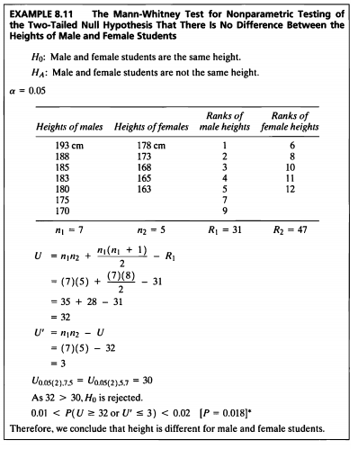

```r
#데이터셋
ex8_11%>%
  kbl(caption = "Dataset",escape=F) %>%
  kable_styling(bootstrap_options = c("striped", "hover", "condensed", "responsive"))
```

Dataset

| exam8_11.sex | exam8_11.height |
| --- | --- |
| 1 | 193 |
| 1 | 188 |
| 1 | 185 |
| 1 | 183 |
| 1 | 180 |
| 1 | 175 |
| 1 | 170 |
| 2 | 178 |
| 2 | 173 |
| 2 | 168 |
| 2 | 165 |
| 2 | 163 |

- 본 데이터는 성인 남성과 여성의 키를 기록한 데이터이다.
- 데이터를 그룹별로 나누어 보자.

```r
hm <- ex8_11 %>% filter(exam8_11.sex=='1')
hf <- ex8_11 %>% filter(exam8_11.sex=='2')

library(qpcR) # 결측치 있는 데이터 cbind
ex8_11_cbind<- data.frame(qpcR:::cbind.na(hm[,2], hf[,2]))
names(ex8_11_cbind) <- c("Heights of males","Heights of females")
```

> males와 females 데이터 수가 차이나기 때문에 cbind가 되지 않으므로 qpcR패키지를 사용하여 결합시켜준다.

```r
ex8_11_cbind%>%
  kbl(caption = "Dataset",escape=F) %>%
  kable_styling(bootstrap_options = c("striped", "hover", "condensed", "responsive"))
```

Dataset

| Heights of males | Heights of females |
| --- | --- |
| 193 | 178 |
| 188 | 173 |
| 185 | 168 |
| 183 | 165 |
| 180 | 163 |
| 175 | NA |
| 170 | NA |

- 남학생과 여학생 키의 차이에 대한 검정을 하고자 한다.
- 일반적인 t-검정을 수행하기엔 표본의 수가 적어 비모수 검정 방법인 Mann-Whitney검정을 실시한다.

$$\begin{aligned}
H_0 &: \ Male \ and \ female \ students\ are\ the\ same\ height.\\
H_A &:\ Male\ and\ female\ students\ are\ not\ the\ same\ height.
\end{aligned}$$

- Mann-Whitney 검정을 하기 위해서는 각 변수의 랭크(순위)를 매겨야하기 때문에 이를 구하도록 한다.  
  (이 예제의 경우 내림차순으로 순위를 구했다. 양측일 경우 문제 없지만 단측일 경우 통계량 값이 바뀐다.)

```r
rank8_11 <- function(data){
  x <- data[,1]
  y <- data[,2]
  h <- as.numeric(rbind(c(x,y)))
  rank <- rank(-h, na.last = "keep")
  gender <- c(rep("m",length(x)),rep("f",length(y)))
  out <- data.frame(h,rank,gender)
  data$rank_m <- subset(out$rank, gender=="m")
  data$rank_f <- subset(out$rank, gender=="f")
  return(data)
}

dat8_11 <- rank8_11(data=ex8_11_cbind)

dat8_11%>%
  kbl(caption = "Result of Rank") %>%
  kable_styling(bootstrap_options = c("striped", "hover", "condensed", "responsive"))
```

Result of Rank

| Heights of males | Heights of females | rank_m | rank_f |
| --- | --- | --- | --- |
| 193 | 178 | 1 | 6 |
| 188 | 173 | 2 | 8 |
| 185 | 168 | 3 | 10 |
| 183 | 165 | 4 | 11 |
| 180 | 163 | 5 | 12 |
| 175 | NA | 7 | NA |
| 170 | NA | 9 | NA |

- Mann-Whitney 검정통계량을 구하는 공식은 다음과 같다.

$$U=n_1n_2 + \frac{n_1(n_1+1)}{2}-R_1$$

$$U'=n_2n_1 + \frac{n_2(n_2+1)}{2}-R_2$$
-
$$U'$$
을 쉽게 구하는 방법이 있다.

$$U'=n_1n_2-U$$

- 본 검정에서 임계값을 테이블을 통해확인하여 보자.

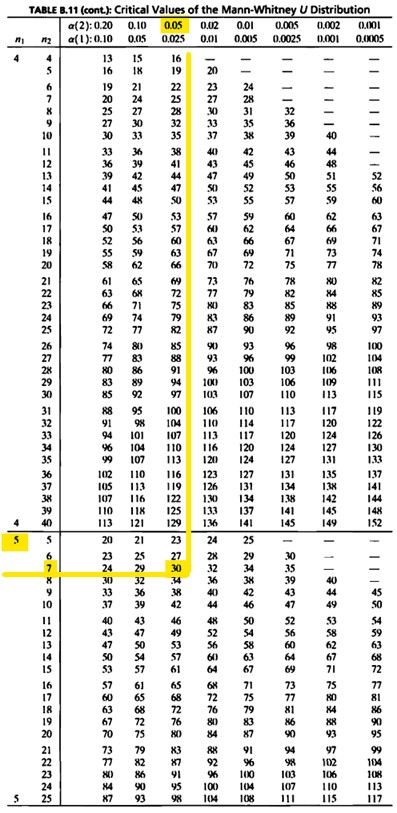

- 양측 0.05 n=5,7의 임계값은 30인 것을 볼 수 있다.

```r
M_W_test <- function(x,y,a,b){
  x <- na.omit(x)
  y <- na.omit(y)
  a <- na.omit(a)
  b <- na.omit(b)
  n1 <- length(x)
  n2 <- length(y)
  r1 <- sum(a)
  r2 <- sum(b)
  u <- n1*n2+(n1*(n1+1)/2)-r1
  u_prime <- n1*n2-u
  out <- data.frame(n1,n2,R1=r1,R2=r2,U=u,U_prime=u_prime)
  return(out)
}
```

```r
M_W_test(dat8_11$`Heights of males`,dat8_11$`Heights of females`,dat8_11$rank_m,dat8_11$rank_f) %>%
  kbl(caption = "Result of Mann-Whitney test") %>%
  kable_styling(bootstrap_options = c("striped", "hover", "condensed", "responsive"))
```

Result of Mann-Whitney test

| n1 | n2 | R1 | R2 | U | U_prime |
| --- | --- | --- | --- | --- | --- |
| 7 | 5 | 31 | 47 | 32 | 3 |

$$U=7*5+\frac{7(7+1)}{2}-31=32$$

$$U'=7*5-32=3$$

- 이 검정은 양측검정이기 때문에
  $$U, \
  U'$$
  중 하나가 임계값보다 크거나 같으면 귀무가설을 기각한다.
- 임계값 U는 30으로 나왔고, 임계값보다 산출된
  $$U$$
  통계량 32가 더 크므로 유의수준 5%하에 귀무가설을 기각할 수 있다.

> 즉, 남학생과 여학생의 키는 유의수준 5%하에서 다르다고 할 수 있다.
- 다음은 R에 내장된 wilcox.text() 를 사용한 결과를 확인하여 보자.

```r
wilcox.test(dat8_11$`Heights of males`, dat8_11$`Heights of females`)
```

```
##
##  Wilcoxon rank sum exact test
##
## data:  dat8_11$`Heights of males` and dat8_11$`Heights of females`
## W = 32, p-value = 0.01768
## alternative hypothesis: true location shift is not equal to 0
```

- wilcoxon rank sum exact test의 p-value=0.018로 유의수준 5%하에서 귀무가설을 기각할 수 있다.  
  그러므로 남학생과 여학생의 키는 다르다고 할 수 있다.

## EXAMPLE 8-12

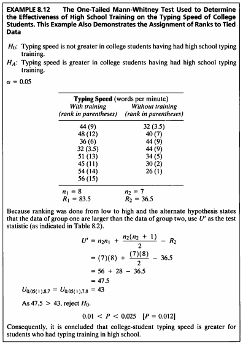

```r
#데이터셋
wt <- c(44,48,36,32,51,45,54,56)
wot <- c(32,40,44,44,34,30,26,NA)
ex8_12 <- data.frame(wt,wot)
ex8_12%>%
  kbl(caption = "Dataset",escape=F) %>%
   kable_styling(bootstrap_options = c("striped", "hover", "condensed", "responsive"))
```

Dataset

| wt | wot |
| --- | --- |
| 44 | 32 |
| 48 | 40 |
| 36 | 44 |
| 32 | 44 |
| 51 | 34 |
| 45 | 30 |
| 54 | 26 |
| 56 | NA |

- 고등학교에서 typing 훈련을 받은 대학생이 훈련을 받지 않은 사람보다 평균속도가 좋은지 검정하고자 한다.

$$\begin{aligned}
H_0 &: Typing\ speed\ is\ not\ greater\ in\ college\ students\
having\ had\ high\ school\ typing\ training. \\
H_A &: Typing\ speed\ is\ greater\ in\ college\ students\ having\
had\ high\ school\ typing\ training.
\end{aligned}$$

- Mann-Whitney 검정을 하기 위해서는 각 변수의 랭크(순위)를 매겨야하기 때문에 이를 구하도록 한다.  
  (이 예제의 경우 오름차순으로 순위를 구했다.)
- 동률 순위 자료가 있는 경우 동률 순위의 평균 순위를 이용한다.

```r
rank8_12 <- function(data){
  x <- data[,1]
  y <- data[,2]
  h <- as.numeric(rbind(c(x,y)))
  rank <- rank(h, na.last = "keep")
  gender <- c(rep("m",length(x)),rep("f",length(y)))
  out <- data.frame(h,rank,gender)
  data$rank_m <- subset(out$rank, gender=="m")
  data$rank_f <- subset(out$rank, gender=="f")
  return(data)
}
dat8_12 <- rank8_12(data=ex8_12)

dat8_12%>%
  kbl(caption = "Result of Rank") %>%
   kable_styling(bootstrap_options = c("striped", "hover", "condensed", "responsive"))
```

Result of Rank

| wt | wot | rank_m | rank_f |
| --- | --- | --- | --- |
| 44 | 32 | 9.0 | 3.5 |
| 48 | 40 | 12.0 | 7.0 |
| 36 | 44 | 6.0 | 9.0 |
| 32 | 44 | 3.5 | 9.0 |
| 51 | 34 | 13.0 | 5.0 |
| 45 | 30 | 11.0 | 2.0 |
| 54 | 26 | 14.0 | 1.0 |
| 56 | NA | 15.0 | NA |

- 이제 Mann-Whitney 검정통계량을 구해 검정을 실시하도록 한다.

```r
M_W_test(dat8_12$wt,dat8_12$wot,dat8_12$rank_m,dat8_12$rank_f) %>%
  kbl(caption = "Result of Mann-Whitney test") %>%
  kable_styling(bootstrap_options = c("striped", "hover", "condensed", "responsive"))
```

Result of Mann-Whitney test

| n1 | n2 | R1 | R2 | U | U_prime |
| --- | --- | --- | --- | --- | --- |
| 8 | 7 | 83.5 | 36.5 | 8.5 | 47.5 |

$$U=8*7+\frac{8(8+1)}{2}-83.5=8.5$$

$$U'=8*7-8.5=47.5$$

- 본 검정에서 임계값을 테이블을 통해확인하여 보자.

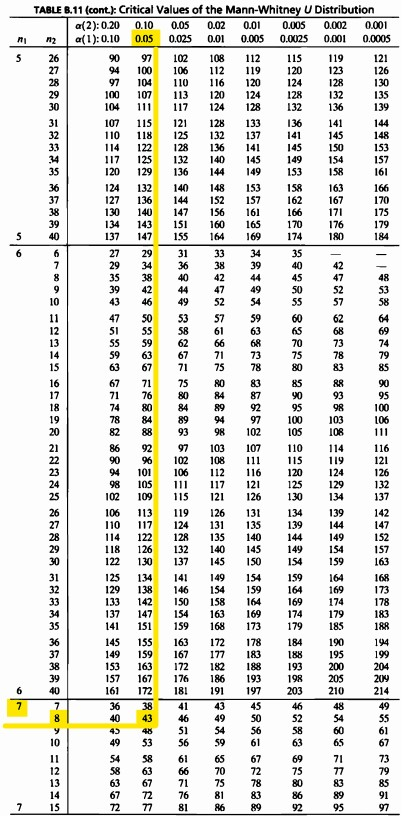

- 단측 0.05 n=7,8의 임계값은 43인 것을 볼 수 있다.
- 이 검정은 단측검정이기 때문에 다음의 표를 확인하여야 한다.

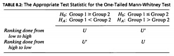

- 이 예제는 오름차순으로 순위가 매겨져 있으며, 훈련받은 학생의 평균속도가 더 좋은지 검정하는 것이기 때문에 통계량을
  $$U'$$
  을 사용한다.
- 임계값은 43으로 나왔고, 임계값보다 산출된
  $$U'$$
  통계량 47.5가 더 크므로 유의수준 5%하에 귀무가설을 기각할 수 있다.

> 즉, 고등학교에서 typing 훈련을 받은 학생은 훈련을 받지 않은 학생보다 typing 평균 속도가 빠르다고 할 수 있다.
- 다음은 R에 내장된 wilcox.text() 를 사용한 결과를 확인하여 보자.

```r
wilcox.test(dat8_12$wt,na.omit(dat8_12$wot),alternative = "greater")
```

```
##
##  Wilcoxon rank sum test with continuity correction
##
## data:  dat8_12$wt and na.omit(dat8_12$wot)
## W = 47.5, p-value = 0.0136
## alternative hypothesis: true location shift is greater than 0
```

## EXAMPLE 8-13

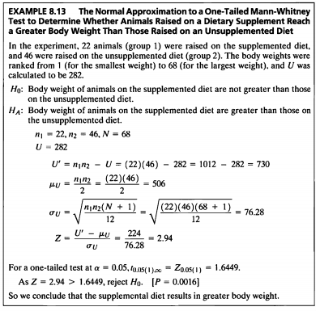

- 본 데이터는 보충제를 섭취 유무에 따른 동물들의 체중을 기록한 데이터로 단측 검정에서의 Mann-Whitney 검정을 실시할 때의 정규 근사를 보여주는 예시이다.
- Mann-Whitney 검정에서 두 그룹의 표본이 20 이상이고 두 표본의 크기 합이 40이상일 경우 정규 근사가 가능하다.
- 각 표본의 sample sizw는 20을 넘어 Mann-Whitney의 정규근사를 이용하여 검정을 수행하였다.

$$\begin{aligned}
H_0 &: Body\ weight\ of\ animals\ on\ the\ supplemented\ diet\ are\
not\ greater\ than\ those\ on\ the\ unsupplemented\ diet. \\
H_A &: Body\ weight\ of\ animals\ on\ the\ supplemented\ diet\ are\
greater\ than\ those\ on\ the\ unsupplemented\ diet.
\end{aligned}$$

> Mann-Whitney의 정규근사를 위한 통계량

$$\mu_U=\frac{n_1n_2}{2} \ (=\frac{U+U'}{2}), \
\sigma_U=\sqrt{\frac{n_1n_1(N+1)}{12}}$$

$$\rightarrow \space Z= \frac{U-\mu_U}{\sigma_U}\ \sim\ N(0,1)$$
-
$$n_1=22,\ n_2=46,\ N=68,\
U=282$$
가 주어졌을 때 검정을 해보도록 한다.

```r
Normal_Approximation_M_W_test<-function(n1,n2,u){
  u_prime<-(n1*n2)-u
  mu<-(n1*n2)/2
  sig<-sqrt(((n1*n2)*(n1+n2+1))/12)
  z<-(u_prime -mu)/sig
  pvalue <- 1-pnorm(z)
  if(pvalue < 0.05){
    Reject_H0 <- "yes"
  }else{
    Reject_H0 <- "No"
  }
  out <- data.frame(u_prime,mu,sig=round(sig,2),z=round(z,2),p_value=round(pvalue,4),Reject_H0)
  return(out)
}
```

```r
Normal_Approximation_M_W_test(22,46,282) %>%
  kbl(caption = "Result of Mann-Whitney test (Normal approxiation)") %>%
  kable_styling(bootstrap_options = c("striped", "hover", "condensed", "responsive"))
```

Result of Mann-Whitney test (Normal approxiation)

| u_prime | mu | sig | z | p_value | Reject_H0 |
| --- | --- | --- | --- | --- | --- |
| 730 | 506 | 76.28 | 2.94 | 0.0017 | yes |

- 이 예제는 오름차순으로 순위가 매겨져 있으며, 음식 보충제를 섭취한 동물의 체중이 음식 보충제를 섭취하지 않은 동물의 체중보다 큰지 검정하는 것이기 때문에 통계량을
  $$U'$$
  을 사용한다.
- 산출된 통계량을 이용하여
  $$Z=\frac{U'-\mu_U}{\sigma_U}=2.94$$
  이고, 표준정규분포에서 유의수준 5% 단측검정 임계값은 1.6449이다.
  계산된 통계량 값이 임계값 보다 크고, 기각역에 포함되므로 귀무가설을 기각할 수 있다.
- 따라서 음식 보충제를 섭취한 동물의 체중은 음식 보충제를 섭취하지 않은 동물의 체중보다 많이 나간다고 말할 수 있다.

## EXAMPLE 8-14

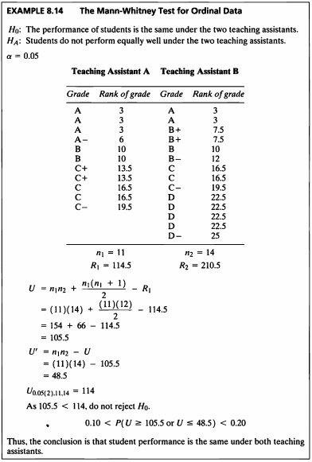

- 연속형 데이터가 아닌 순서(순위)만 있는 데이터의 검정을 해보도록 한다.
- 본 데이터는 수업 조교에 따른 학생들의 성적 등급을 기록한 데이터로 수업 조교에 따른 학생들의 등급이 같은지 다른지 검정해보도록 한다.

```r
A <- c(3,3,3,6,10,10,13.5,13.5,16.5,16.5,19.5,NA,NA,NA)
B <- c(3,3,7.5,7.5,10,12,16.5,16.5,19.5,22.5,22.5,22.5,22.5,25)
ex8_14 <- data.frame(A,B)
ex8_14%>%
  kbl(caption = "Dataset",escape=F) %>%
   kable_styling(bootstrap_options = c("striped", "hover", "condensed", "responsive"))
```

Dataset

| A | B |
| --- | --- |
| 3.0 | 3.0 |
| 3.0 | 3.0 |
| 3.0 | 7.5 |
| 6.0 | 7.5 |
| 10.0 | 10.0 |
| 10.0 | 12.0 |
| 13.5 | 16.5 |
| 13.5 | 16.5 |
| 16.5 | 19.5 |
| 16.5 | 22.5 |
| 19.5 | 22.5 |
| NA | 22.5 |
| NA | 22.5 |
| NA | 25.0 |

```r
rank_M_W_test <- function(x,y){
  x <- na.omit(x)
  y <- na.omit(y)
  n1 <- length(x)
  n2 <- length(y)
  r1 <- sum(x)
  r2 <- sum(y)
  u <- n1*n2+(n1*(n1+1)/2)-min(r1,r2)
  u_prime <- n1*n2-u
  out <- data.frame(n1,n2,R1=r1,R2=r2,U=u,U_prime=u_prime)
  return(out)
}
```

```r
rank_M_W_test(ex8_14$A,ex8_14$B)%>%
  kbl(caption = "Result of Mann-Whitney test (Normal approxiation)") %>%
  kable_styling(bootstrap_options = c("striped", "hover", "condensed", "responsive"))
```

| n1 | n2 | R1 | R2 | U | U_prime |
| --- | --- | --- | --- | --- | --- |
| 11 | 14 | 114.5 | 210.5 | 105.5 | 48.5 |

- $$U$$
  통계량은 주어진 공식에 따라
  $$U, U'$$
  을 모두 구하고 둘 중 큰 값을
  $$U$$
  통계량으로 한다.**
- 계산 결과
  $$U=105.5, \
  U'=48.5$$
  로
  $$U$$
  값이 더 크기 때문에 통계량은 105.5가 된다.

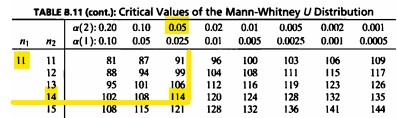

- 임계값은 U_0.05(11,14)=114이므로 통계량이 임계값보다 작아 귀무가설을 기각할 수 없고 따라서 어시스턴트에 따라 학생들의 학업 성취도가 다르다고 말할 수 없다.**
- 다음은 R에 내장된 wilcox.text() 를 사용한 결과이다.

```r
wilcox.test(na.omit(ex8_14$A),ex8_14$B,alternative = "two.sided")
```

```
##
##  Wilcoxon rank sum test with continuity correction
##
## data:  na.omit(ex8_14$A) and ex8_14$B
## W = 48.5, p-value = 0.1219
## alternative hypothesis: true location shift is not equal to 0
```

- wil.cox test를 이용해 검정할 수도 있으며 패키지를 이용해 wilcox.test검정을 진행한 결과 p-value가 0.1219로 유의수준 0.05보다 크기 때문에 귀무가설을 기각할 수 없다.

## EXAMPLE 8-15

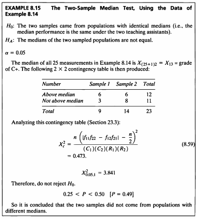

- Example 8.14 데이터를 사용해서 중위수 검정을 실시해보도록 한다.

```r
data <- c(na.omit(ex8_14$A),ex8_14$B)
ex8_15 <- data.frame(data)
ex8_15$number <- ifelse(ex8_15$data > median(ex8_15$data) ,
                         ex8_15$number <- "Not above Median",ifelse(ex8_15$data == median(ex8_15$data),NA,ex8_15$number <- "Above Median"))
group<-c(rep("Sample 1",11), rep("Sample 2",14))
ex8_15$group <- group
ex8_15 <- na.omit(ex8_15)
table(ex8_15$number,ex8_15$group)%>%
  kbl(caption = "Result of Mann-Whitney test") %>%
  kable_styling(bootstrap_options = c("striped", "hover", "condensed", "responsive"))
```

|  | Sample 1 | Sample 2 |
| --- | --- | --- |
| Above Median | 6 | 6 |
| Not above Median | 3 | 8 |

- 교차표를 보면 1번 그룹에선 중위수를 넘는 학생이 6명이고 넘지 않는 학생이 3명이며, 2번 그룹에서는 6명과 8명이다.
- 중위수 검정을 하기 위해 pearson 카이제곱 검정을 실시한다. 카이제곱 검정을 하기 위한 검정통계량 공식은 다음과 같다.

$$\chi_c^2 = \frac{n\ (|f_{11}f_{22}\ -\ f_{12}f_{21}|\ -\
\frac{n}{2})^2}{(C_1)(C_2)(R_1)(R_2)} \ \sim \chi_1^2$$

```r
chi_square_test<- function(table){
  tab <- table
  f11 <- tab[1,1]
  f22 <- tab[2,2]
  f12 <- tab[1,2]
  f21 <- tab[2,1]
  C1 <- sum(tab[,1])
  C2 <- sum(tab[,2])
  R1 <- sum(tab[1,])
  R2 <- sum(tab[2,])
  n <- sum(R1,R2)
  chis <- (n*(abs(f11*f22-f12*f21)-(n/2))^2)/(C1*C2*R1*R2)
  pvalue <- min(pchisq(chis,1),1-pchisq(chis,1))
  out <- data.frame(chi=round(chis,3),pvalue=round(pvalue,2))
  return(out)
}

chi_square_test(table(ex8_15$number,ex8_15$group))%>%
  kbl(caption = "Result of Chi-square test") %>%
  kable_styling(bootstrap_options = c("striped", "hover", "condensed", "responsive"))
```

Result of Chi-square test

| chi | pvalue |
| --- | --- |
| 0.473 | 0.49 |

- 빈도표를 생성하여 산출한 통계량은 0.473이고, 자유도가 1인 카이제곱 통계량은 3.841임을 알 수 있다.
- 통계량이 기각역에 포함되지 않으므로 귀무가설을 기각할 수 없다.
- 즉, 같은 모집단으로부터 추출된 두 표본의 중위수는 다르다고 할 수 없다.
- 그러므로 수업 조교에 따른 학생들의 성적 등급의 중위수가 다르다고 할 수 없다.
- RVAideMemoire 패키지 내에 있는 mood.medtest() 함수를 사용한 결과를 확인하여 보자.

```r
library(RVAideMemoire)
mood.medtest(ex8_15$data~ex8_15$group,exact=F)
```

```
##
##  Mood's median test
##
## data:  ex8_15$data by ex8_15$group
## X-squared = 0.47329, df = 1, p-value = 0.4915
```

## EXAMPLE 8-16

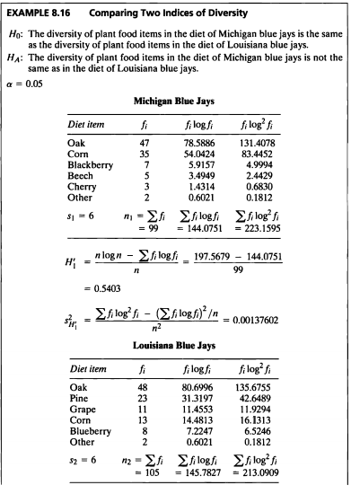

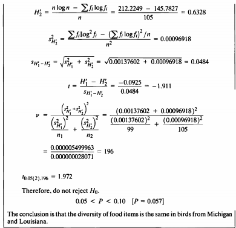

```r
Michigan <- c(47,35,7,5,3,2)
Louisiana <- c(48,23,11,13,8,2)
ex8_16 <- data.frame(Michigan,Louisiana)
ex8_16%>%
  kbl(caption = "Dataset",escape=F) %>%
  kable_styling(bootstrap_options = c("striped", "hover", "condensed", "responsive"))
```

Dataset

| Michigan | Louisiana |
| --- | --- |
| 47 | 48 |
| 35 | 23 |
| 7 | 11 |
| 5 | 13 |
| 3 | 8 |
| 2 | 2 |

- 이 데이터는 미시간 블루제이스의 식단에서 식물성 식품의 빈도와 루이지애나 블루제이스의 식단에서 식물성 식품의 빈도 데이터이다.
- 독립적인 두개의 표본에 대하여 다양성 지수 차이를 검정하기 위해서는 Shannon index H 를 구하고 허치슨이 제안한 검정통계량을 구하여 검정을 진행하여야 한다.

$$\begin{aligned}
H_0 &: H_1 = H_2\\
H_A &: H_1 \ne H_2
\end{aligned}$$

- 통계량들을 구하는 공식은 다음과 같다.

```r
H_test<- function(x,y){
  n1 <- sum(x)
  filog_1 <- sum(x*log10(x))
  filog2_1 <- sum(x*log10(x)^2)
  h1 <- (n1*log10(n1)-filog_1)/n1
  sh1 <- (filog2_1-(filog_1^2/n1))/n1^2
  n2 <- sum(y)
  filog_2 <- sum(y*log10(y))
  filog2_2 <- sum(y*log10(y)^2)
  h2 <- (n2*log10(n2)-filog_2)/n2
  sh2 <- (filog2_2-(filog_2^2/n2))/n2^2
  s_h1_h2 <- sqrt(sh1+sh2)
  t <- (h1-h2)/s_h1_h2
  v <- (sh1+sh2)^2/( (sh1^2/n1) + (sh2^2/n2) )
  pvalue <- 2*min(pt(t,v),1-pt(t,v))
  if(pvalue < 0.05){
    Reject_H0 <- "yes"
  }else{
    Reject_H0 <- "No"
  }
  out <- data.frame(h1=round(h1,4),h2=round(h2,4),sh1,sh2,s_h1_h2=round(s_h1_h2,4),t=round(t,3),v=round(v),p_value=round(pvalue,3),Reject_H0)
  return(out)
}
```

```r
H_test(ex8_16$Michigan,ex8_16$Louisiana)%>%
  kbl(caption = "Result of indices of diversity") %>%
  kable_styling(bootstrap_options = c("striped", "hover", "condensed", "responsive"))
```

Result of indices of diversity

| h1 | h2 | sh1 | sh2 | s_h1_h2 | t | v | p_value | Reject_H0 |
| --- | --- | --- | --- | --- | --- | --- | --- | --- |
| 0.5403 | 0.6328 | 0.001376 | 0.0009692 | 0.0484 | -1.909 | 196 | 0.058 | No |

- 다양성 지수
  $$H$$
  는 vegan 패키지에 있는 diversity() 함수를 사용해서도 계산이 가능하다.

```r
library(vegan)
h1_1<-diversity(ex8_16$Michigan, index="shannon", base=10)
h2_2<-diversity(ex8_16$Louisiana, index="shannon", base=10)
c(round(h1_1,4),round(h2_2,4))==c(H_test(ex8_16$Michigan,ex8_16$Louisiana)$h1,H_test(ex8_16$Michigan,ex8_16$Louisiana)$h2)
```

```
## [1] TRUE TRUE
```

```r
cat(" diversity() 함수로 구한 다양성 지수 : H1 = ",round(h1_1,4),"  H2 = ",round(h2_2,4),"\n",
    "직접 코딩한 함수로 구한 다양성 지수 : H1 = ",H_test(ex8_16$Michigan,ex8_16$Louisiana)$h1,"  H2 = ",H_test(ex8_16$Michigan,ex8_16$Louisiana)$h2,"\n",
    "두 다양성 지수가 동일한가?  H1 : ",round(h1_1,4)==H_test(ex8_16$Michigan,ex8_16$Louisiana)$h1,"   H2 : ",round(h2_2,4)==H_test(ex8_16$Michigan,ex8_16$Louisiana)$h2)
```

```
##  diversity() 함수로 구한 다양성 지수 : H1 =  0.5403   H2 =  0.6328
##  직접 코딩한 함수로 구한 다양성 지수 : H1 =  0.5403   H2 =  0.6328
##  두 다양성 지수가 동일한가?  H1 :  TRUE    H2 :  TRUE
```